# Homework 2

## Problem 1

ISL Chapter 3 Problem 9. This problem involves linear regression of the Auto dataset from the last homework. The dataset is available on Webcourses in the file Auto.csv. This dataset is referenced in the text of both Chapters 2 and 3 and you can look at the information there as a guideline. One important thing to note is that you should omit rows with missing entries using the na.omit() function in R or the or the df.dropna() function in pandas, where df is your dataframe. (Note: In general, omitting NA values might bias your results. But data imputation can be involved so for now we will just remove missing entries).

#### 9) This question involves the use of multiple linear regression on the Auto data set.

```python
import pandas as pa;
file_path = 'C:/Users/danma/Downloads/STA 4364/Assignment 2/Auto.csv'
df = pa.read_csv(file_path)
df = df[df['horsepower'] != '?']
df['horsepower'] = df['horsepower'].astype(int)
df.head()
```

|  | mpg | cylinders | displacement | horsepower | weight | acceleration | year | origin | name |
| --- | --- | --- | --- | --- | --- | --- | --- | --- | --- |
| 0 | 18.0 | 8 | 307.0 | 130 | 3504 | 12.0 | 70 | 1 | chevrolet chevelle malibu |
| 1 | 15.0 | 8 | 350.0 | 165 | 3693 | 11.5 | 70 | 1 | buick skylark 320 |
| 2 | 18.0 | 8 | 318.0 | 150 | 3436 | 11.0 | 70 | 1 | plymouth satellite |
| 3 | 16.0 | 8 | 304.0 | 150 | 3433 | 12.0 | 70 | 1 | amc rebel sst |
| 4 | 17.0 | 8 | 302.0 | 140 | 3449 | 10.5 | 70 | 1 | ford torino |

#### (a) Produce a scatterplot matrix which includes all of the variables in the data set.

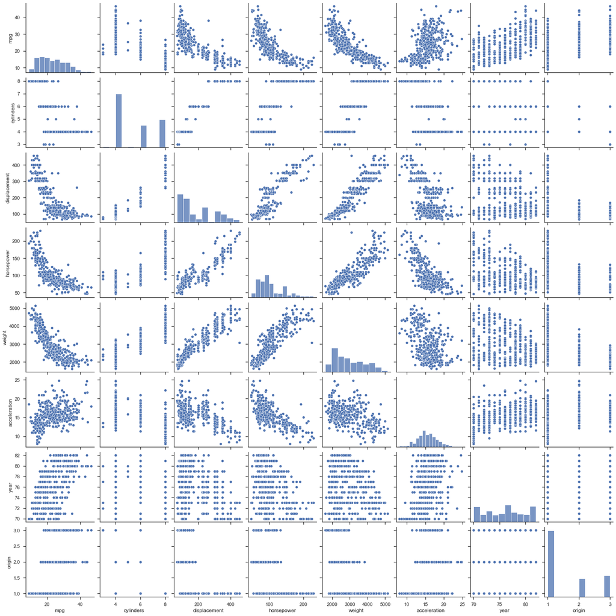

```python
import seaborn as sns
sns.set_theme(style="ticks")

sns.pairplot(df)
```

#### (b) Compute the matrix of correlations between the variables using the function cor(). You will need to exclude the name variable, cor() which is qualitative.

```python
df_quant = df.drop(['name'],axis=1)
df_quant.corr()
```

|  | mpg | cylinders | displacement | horsepower | weight | acceleration | year | origin |
| --- | --- | --- | --- | --- | --- | --- | --- | --- |
| mpg | 1.000000 | -0.777618 | -0.805127 | -0.778427 | -0.832244 | 0.423329 | 0.580541 | 0.565209 |
| cylinders | -0.777618 | 1.000000 | 0.950823 | 0.842983 | 0.897527 | -0.504683 | -0.345647 | -0.568932 |
| displacement | -0.805127 | 0.950823 | 1.000000 | 0.897257 | 0.932994 | -0.543800 | -0.369855 | -0.614535 |
| horsepower | -0.778427 | 0.842983 | 0.897257 | 1.000000 | 0.864538 | -0.689196 | -0.416361 | -0.455171 |
| weight | -0.832244 | 0.897527 | 0.932994 | 0.864538 | 1.000000 | -0.416839 | -0.309120 | -0.585005 |
| acceleration | 0.423329 | -0.504683 | -0.543800 | -0.689196 | -0.416839 | 1.000000 | 0.290316 | 0.212746 |
| year | 0.580541 | -0.345647 | -0.369855 | -0.416361 | -0.309120 | 0.290316 | 1.000000 | 0.181528 |
| origin | 0.565209 | -0.568932 | -0.614535 | -0.455171 | -0.585005 | 0.212746 | 0.181528 | 1.000000 |

#### (c) Use the lm() function to perform a multiple linear regression with mpg as the response and all other variables except name as the predictors. Use the summary() function to print the results. Comment on the output. For instance:

i. Is there a relationship between the predictors and the response?

ii. Which predictors appear to have a statistically significant relationship to the response?

iii. What does the coefficient for the year variable suggest?

```python
#regresssuib linear model
import numpy as np;
import statsmodels.api as sm;
x = df_quant.drop(['mpg'],axis=1)
y = df_quant['mpg']
result = sm.OLS(y,x).fit()
print(result.summary())
print("\nResidual Standard Error:")
print(np.sqrt(result.mse_resid))
```

```
                                 OLS Regression Results
=======================================================================================
Dep. Variable:                    mpg   R-squared (uncentered):                   0.982
Model:                            OLS   Adj. R-squared (uncentered):              0.981
Method:                 Least Squares   F-statistic:                              2933.
Date:                Mon, 26 Sep 2022   Prob (F-statistic):                        0.00
Time:                        23:51:57   Log-Likelihood:                         -1030.4
No. Observations:                 392   AIC:                                      2075.
Df Residuals:                     385   BIC:                                      2103.
Df Model:                           7
Covariance Type:            nonrobust
================================================================================
                   coef    std err          t      P>|t|      [0.025      0.975]
--------------------------------------------------------------------------------
cylinders       -0.7055      0.323     -2.181      0.030      -1.341      -0.070
displacement     0.0219      0.008      2.871      0.004       0.007       0.037
horsepower      -0.0396      0.013     -3.147      0.002      -0.064      -0.015
weight          -0.0060      0.001     -9.258      0.000      -0.007      -0.005
acceleration    -0.0796      0.090     -0.881      0.379      -0.257       0.098
year             0.5836      0.024     24.150      0.000       0.536       0.631
origin           1.3100      0.281      4.663      0.000       0.758       1.862
==============================================================================
Omnibus:                       46.837   Durbin-Watson:                   1.283
Prob(Omnibus):                  0.000   Jarque-Bera (JB):               90.015
Skew:                           0.681   Prob(JB):                     2.84e-20
Kurtosis:                       4.912   Cond. No.                     6.00e+03
==============================================================================

Notes:
[1] R² is computed without centering (uncentered) since the model does not contain a constant.
[2] Standard Errors assume that the covariance matrix of the errors is correctly specified.
[3] The condition number is large,  6e+03. This might indicate that there are
strong multicollinearity or other numerical problems.

Residual Standard Error:
3.3823140014793305
```

i. Is there a relationship between the predictors and the response?  
**There are multiple predictors with a relationship with the response, this can be seen by looking at the P>|t| column p-values. Acceleration having the 'weakest' relationship.**

iii. What does the coefficient for the year variable suggest?  
**The coefficient for the year is 0.5836 which means, with every other predictor held constant, the mpg value increases by 0.5836 each year.**

#### (d) Use the plot() function to produce diagnostic plots of the linear regression fit. Comment on any problems you see with the fit. Do the residual plots suggest any unusually large outliers? Does the leverage plot identify any observations with unusually high leverage?

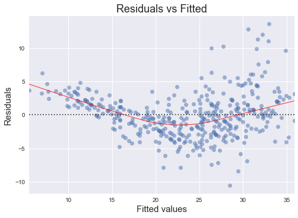

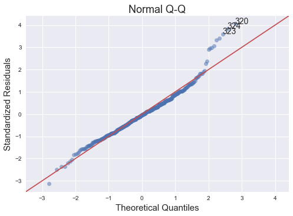

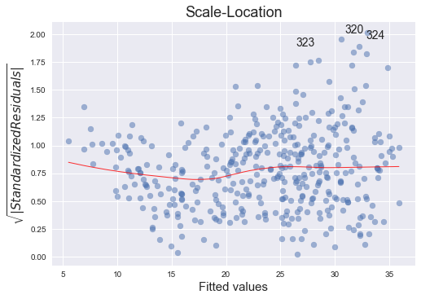

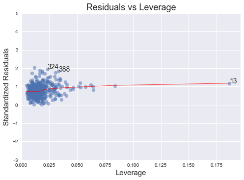

```python
import matplotlib.pyplot as plt
plt.style.use('seaborn') # pretty matplotlib plots
plt.rc('font', size=14)
plt.rc('figure', titlesize=18)
plt.rc('axes', labelsize=15)
plt.rc('axes', titlesize=18)

#Residuals vs Fitted Plot
plot_lm_1 = plt.figure()
plot_lm_1.axes[0] = sns.residplot(x=result.fittedvalues, y=y, data=df,
                          lowess=True,
                          scatter_kws={'alpha': 0.5},
                          line_kws={'color': 'red', 'lw': 1, 'alpha': 0.8})

plot_lm_1.axes[0].set_title('Residuals vs Fitted')
plot_lm_1.axes[0].set_xlabel('Fitted values')
plot_lm_1.axes[0].set_ylabel('Residuals')

from statsmodels.graphics.gofplots import ProbPlot
import numpy as np
#Normal Q-Q Plot
QQ = ProbPlot(result.get_influence().resid_studentized_internal)
plot_lm_2 = QQ.qqplot(line='45', alpha=0.5, lw=1)
plot_lm_2.axes[0].set_title('Normal Q-Q')
plot_lm_2.axes[0].set_xlabel('Theoretical Quantiles')
plot_lm_2.axes[0].set_ylabel('Standardized Residuals');
# annotations
abs_norm_resid = np.flip(np.argsort(np.abs(result.get_influence().resid_studentized_internal)), 0)
abs_norm_resid_top_3 = abs_norm_resid[:3]
for r, i in enumerate(abs_norm_resid_top_3):
    plot_lm_2.axes[0].annotate(i,
                               xy=(np.flip(QQ.theoretical_quantiles, 0)[r],
                                   result.get_influence().resid_studentized_internal[i]));
#Scale-Location Plot
plot_lm_3 = plt.figure()
plt.scatter(x=result.fittedvalues, y=np.sqrt(np.abs(result.get_influence().resid_studentized_internal)), alpha=0.5);
sns.regplot(x=result.fittedvalues, y=np.sqrt(np.abs(result.get_influence().resid_studentized_internal)),
              scatter=False,
              ci=False,
              lowess=True,
              line_kws={'color': 'red', 'lw': 1, 'alpha': 0.8});
plot_lm_3.axes[0].set_title('Scale-Location')
plot_lm_3.axes[0].set_xlabel('Fitted values')
plot_lm_3.axes[0].set_ylabel('$\sqrt{|Standardized Residuals|}$');

# annotations
abs_sq_norm_resid = np.flip(np.argsort(np.sqrt(np.abs(result.get_influence().resid_studentized_internal))), 0)
abs_sq_norm_resid_top_3 = abs_sq_norm_resid[:3]
for i in abs_norm_resid_top_3:
      plot_lm_3.axes[0].annotate(i,
                                 xy=(result.fittedvalues[i],
                                     np.sqrt(np.abs(result.get_influence().resid_studentized_internal))[i]));

plot_lm_4 = plt.figure();
plt.scatter(x=result.get_influence().hat_matrix_diag, y=np.sqrt(np.abs(result.get_influence().resid_studentized_internal)), alpha=0.5);
sns.regplot(x=result.get_influence().hat_matrix_diag, y=np.sqrt(np.abs(result.get_influence().resid_studentized_internal)),
              scatter=False,
              ci=False,
              lowess=True,
              line_kws={'color': 'red', 'lw': 1, 'alpha': 0.8});
plot_lm_4.axes[0].set_xlim(0, max(result.get_influence().hat_matrix_diag)+0.01)
plot_lm_4.axes[0].set_ylim(-3, 5)
plot_lm_4.axes[0].set_title('Residuals vs Leverage')
plot_lm_4.axes[0].set_xlabel('Leverage')
plot_lm_4.axes[0].set_ylabel('Standardized Residuals');

# annotations
leverage_top_3 = np.flip(np.argsort(result.get_influence().cooks_distance[0]), 0)[:3]
for i in leverage_top_3:
      plot_lm_4.axes[0].annotate(i,
                                 xy=(result.get_influence().hat_matrix_diag[i],
                                     np.sqrt(np.abs(result.get_influence().resid_studentized_internal))[i]));
```

#### (e) Use the * and : symbols to fit linear regression models with interaction effects. Do any interactions appear to be statistically significant?

```python
#regresssuib linear model
import statsmodels.formula.api as smf
result = smf.ols('mpg ~ horsepower*displacement', data=df_quant).fit()
print(result.summary())
#regresssuib linear model
import statsmodels.formula.api as smf
result = smf.ols('mpg ~ displacement:weight', data=df_quant).fit()
print(result.summary())
#regresssuib linear model
import statsmodels.formula.api as smf
result = smf.ols('mpg ~ displacement:cylinders+displacement:weight+acceleration:horsepower', data=df_quant).fit()
print(result.summary())
#regresssuib linear model
import statsmodels.formula.api as smf
result = smf.ols('mpg ~ displacement:cylinders+displacement:weight+year:origin+acceleration:horsepower', data=df_quant).fit()
print(result.summary())
#regresssuib linear model
import statsmodels.formula.api as smf
result = smf.ols('mpg ~ year:origin+displacement:weight+displacement:weight+acceleration:horsepower+acceleration:weight', data=df_quant).fit()
print(result.summary())
```

```
                            OLS Regression Results
==============================================================================
Dep. Variable:                    mpg   R-squared:                       0.747
Model:                            OLS   Adj. R-squared:                  0.745
Method:                 Least Squares   F-statistic:                     381.0
Date:                Mon, 26 Sep 2022   Prob (F-statistic):          3.00e-115
Time:                        23:51:58   Log-Likelihood:                -1092.1
No. Observations:                 392   AIC:                             2192.
Df Residuals:                     388   BIC:                             2208.
Df Model:                           3
Covariance Type:            nonrobust
===========================================================================================
                              coef    std err          t      P>|t|      [0.025      0.975]
-------------------------------------------------------------------------------------------
Intercept                  53.0511      1.526     34.765      0.000      50.051      56.051
horsepower                 -0.2343      0.020    -11.960      0.000      -0.273      -0.196
displacement               -0.0980      0.007    -14.674      0.000      -0.111      -0.085
horsepower:displacement     0.0006   5.19e-05     11.222      0.000       0.000       0.001
==============================================================================
Omnibus:                       46.481   Durbin-Watson:                   1.057
Prob(Omnibus):                  0.000   Jarque-Bera (JB):               87.417
Skew:                           0.685   Prob(JB):                     1.04e-19
Kurtosis:                       4.865   Cond. No.                     2.47e+05
==============================================================================

Notes:
[1] Standard Errors assume that the covariance matrix of the errors is correctly specified.
[2] The condition number is large, 2.47e+05. This might indicate that there are
strong multicollinearity or other numerical problems.
                            OLS Regression Results
==============================================================================
Dep. Variable:                    mpg   R-squared:                       0.629
Model:                            OLS   Adj. R-squared:                  0.628
Method:                 Least Squares   F-statistic:                     659.8
Date:                Mon, 26 Sep 2022   Prob (F-statistic):           7.02e-86
Time:                        23:51:58   Log-Likelihood:                -1167.1
No. Observations:                 392   AIC:                             2338.
Df Residuals:                     390   BIC:                             2346.
Df Model:                           1
Covariance Type:            nonrobust
```

[output cut: 90 more lines]

```
year:origin                 0.0263      0.004      6.274      0.000       0.018       0.035
displacement:weight     -4.786e-06    7.7e-07     -6.215      0.000    -6.3e-06   -3.27e-06
acceleration:horsepower    -0.0092      0.001     -7.829      0.000      -0.011      -0.007
acceleration:weight      3.778e-05   2.73e-05      1.384      0.167   -1.59e-05    9.15e-05
==============================================================================
Omnibus:                       33.644   Durbin-Watson:                   1.104
Prob(Omnibus):                  0.000   Jarque-Bera (JB):               46.002
Skew:                           0.631   Prob(JB):                     1.03e-10
Kurtosis:                       4.105   Cond. No.                     5.60e+06
==============================================================================

Notes:
[1] Standard Errors assume that the covariance matrix of the errors is correctly specified.
[2] The condition number is large, 5.6e+06. This might indicate that there are
strong multicollinearity or other numerical problems.
```

#### (f) Try a few different transformations of the variables, such as log(X), √ X, X^2. Comment on your findings.

```python
#regresssuib linear model
import statsmodels.formula.api as smf
result = smf.ols('mpg ~ acceleration+np.log(acceleration)', data=df_quant).fit()
print(result.summary())
#regresssuib linear model
import statsmodels.formula.api as smf
result = smf.ols('mpg ~ I(horsepower^2)', data=df_quant).fit()
print(result.summary())
```

```
                            OLS Regression Results
==============================================================================
Dep. Variable:                    mpg   R-squared:                       0.194
Model:                            OLS   Adj. R-squared:                  0.190
Method:                 Least Squares   F-statistic:                     46.73
Date:                Mon, 26 Sep 2022   Prob (F-statistic):           6.48e-19
Time:                        23:51:58   Log-Likelihood:                -1319.0
No. Observations:                 392   AIC:                             2644.
Df Residuals:                     389   BIC:                             2656.
Df Model:                           2
Covariance Type:            nonrobust
========================================================================================
                           coef    std err          t      P>|t|      [0.025      0.975]
----------------------------------------------------------------------------------------
Intercept              -59.8670     24.535     -2.440      0.015    -108.105     -11.629
acceleration            -1.2491      0.934     -1.338      0.182      -3.085       0.586
np.log(acceleration)    37.6631     14.233      2.646      0.008       9.679      65.647
==============================================================================
Omnibus:                       16.257   Durbin-Watson:                   0.674
Prob(Omnibus):                  0.000   Jarque-Bera (JB):               16.972
Skew:                           0.485   Prob(JB):                     0.000206
Kurtosis:                       2.686   Cond. No.                     1.28e+03
==============================================================================

Notes:
[1] Standard Errors assume that the covariance matrix of the errors is correctly specified.
[2] The condition number is large, 1.28e+03. This might indicate that there are
strong multicollinearity or other numerical problems.
                            OLS Regression Results
==============================================================================
Dep. Variable:                    mpg   R-squared:                       0.605
Model:                            OLS   Adj. R-squared:                  0.604
Method:                 Least Squares   F-statistic:                     597.0
Date:                Mon, 26 Sep 2022   Prob (F-statistic):           1.21e-80
Time:                        23:51:58   Log-Likelihood:                -1179.2
No. Observations:                 392   AIC:                             2362.
Df Residuals:                     390   BIC:                             2370.
Df Model:                           1
Covariance Type:            nonrobust
=====================================================================================
                        coef    std err          t      P>|t|      [0.025      0.975]
-------------------------------------------------------------------------------------
Intercept            39.9437      0.719     55.525      0.000      38.529      41.358
I(horsepower ^ 2)    -0.1580      0.006    -24.433      0.000      -0.171      -0.145
==============================================================================
Omnibus:                       19.161   Durbin-Watson:                   0.929
Prob(Omnibus):                  0.000   Jarque-Bera (JB):               20.588
Skew:                           0.533   Prob(JB):                     3.38e-05
Kurtosis:                       3.350   Cond. No.                         323.
==============================================================================

Notes:
[1] Standard Errors assume that the covariance matrix of the errors is correctly specified.
```

**Log(acceleration) is still very significant and is more significant than acceleration alone.**

## Problem 2

Analyze the Air Quality dataset provided in Webcourses (file is AirQuality.csv). This data was collected hourly in Beijing from January 1, 2010 to December 31, 2014. We are interested in PM2.5 concentration as the response variable. The dataset attributes are:  
• No: row number  
• year: year of data in this row  
• month: month of data in this row  
• day: day of data in this row  
• hour: hour of data in this row  
• pm2.5: PM2.5 concentration (ug/m3)  
• DEWP: Dew Point  
• TEMP: Temperature  
• PRES: Pressure  
• cbwd: Combined wind direction (cv is SW)  
• Iws: Cumulated wind speed (m/s)  
• Is: Cumulated hours of snow  
• Ir: Cumulated hours of rain

#### Prepare the dataset: load the data, omit rows with NA entries. Plot the histogram of PM2.5. Since this variable is clustered around 0, it’s best to take a log transformation to make the data more symmetric and unimodal. Remove 0 entries for PM2.5 to avoid −∞ values when doing the log transform (there are only 2 observations with PM2.5 of 0 so this is not a problem. In general care should be taken with 0 entries when doing log transforms to avoid taking the log of 0).

```
              datetime  No  year month day hour  pm2.5  DEWP  TEMP    PRES  \
24 2010-01-02 00:00:00  25  2010     1   2    0  129.0   -16  -4.0  1020.0
25 2010-01-02 01:00:00  26  2010     1   2    1  148.0   -15  -4.0  1020.0
26 2010-01-02 02:00:00  27  2010     1   2    2  159.0   -11  -5.0  1021.0
27 2010-01-02 03:00:00  28  2010     1   2    3  181.0    -7  -5.0  1022.0
28 2010-01-02 04:00:00  29  2010     1   2    4  138.0    -7  -5.0  1022.0

   cbwd   Iws  Is  Ir
24   SE  1.79   0   0
25   SE  2.68   0   0
26   SE  3.57   0   0
27   SE  5.36   1   0
28   SE  6.25   2   0
```

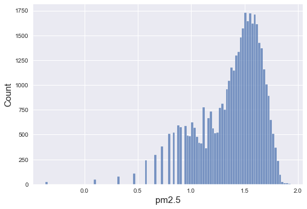

```python
#Load Dataset
import pandas as pa;
import numpy as np;
import seaborn as sns;
file_path = 'C:/Users/danma/Downloads/STA 4364/Assignment 2/AirQuality.csv'
df = pa.read_csv(file_path,parse_dates= {"datetime" : ["year","month","day","hour"]},date_parser=lambda x: pa.datetime.strptime(x, '%Y %m %d %H'),keep_date_col=True)
#omit rows with NA entries
df = df.dropna()
print(df.head())
#Plot histogram of PM2.5, take log transformation, remove 0 entries
#remove 0 entries
df = df.loc[df['pm2.5'] != 0]
#log transformation
df['pm2.5'] = df['pm2.5'].apply(np.log)
#plot histogram
sns.histplot(data=df['pm2.5'].apply(np.log))
```

#### Do an exploratory analysis on the data. Make plots or perform calculations to investigate the following questions:

• Does pollution appear to be increasing, decreasing, or neither over time?  
• Are certain months, days of the month, or hours of the day, associated with greater pollution?  
• Are environmental factors associated with greater or less pollution?  
• Are there relations between the environmental factors?

[output not shown]

[figure not shown]

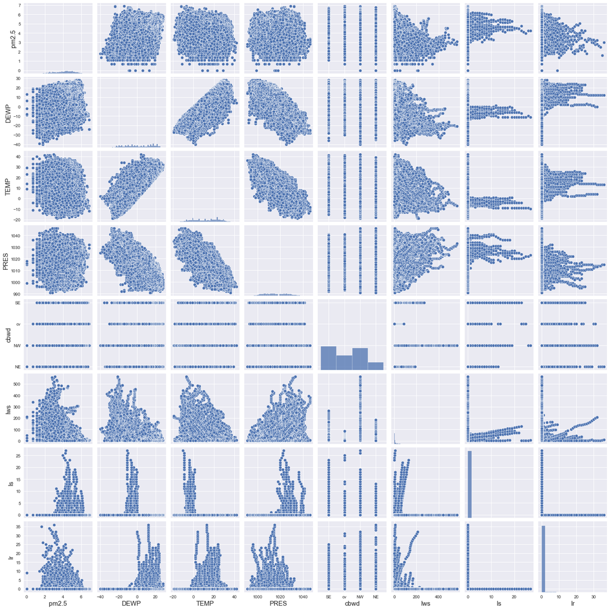

```python
import matplotlib.pyplot as plt
plt.style.use('seaborn') # pretty matplotlib plots
plt.rc('font', size=14)
plt.rc('figure', titlesize=18)
plt.rc('axes', labelsize=15)
plt.rc('axes', titlesize=18)

fig, axs = plt.subplots(nrows=2,ncols=2,figsize=(20, 20),dpi=500)
sns.boxplot(x='year', y='pm2.5', data=df,ax=axs[0,0])
sns.boxplot(x='month', y='pm2.5', data=df,ax=axs[0,1])
sns.boxplot(x='day', y='pm2.5', data=df,ax=axs[1,0])
sns.boxplot(x='hour', y='pm2.5', data=df,ax=axs[1,1])

plotEx_1 = plt.figure(figsize=(50,25),dpi=500)
plotEx_1.axes[0] = sns.pairplot(df, vars=['pm2.5','DEWP', 'TEMP', 'PRES', 'cbwd', 'Iws', 'Is', 'Ir'], palette='Paired', kind='scatter')
```

• Does pollution appear to be increasing, decreasing, or neither over time? **Overtime the pollution appears to remain the same, as seen on the year box plot with the medians remaining similar and means overlapping.**  
• Are certain months, days of the month, or hours of the day, associated with greater pollution? **It appears that the winter months 1-3 and 10-12 have the greatest variation in pollution covering a larger range, while the medians for months 4-9 are larger, leading to the overall pollution being greater in those months. The inverse of this can be seen for hours, showing the midday hours with the largest range and ending/beginning hours of the day with the greater median and mean pollution.**  
• Are environmental factors associated with greater or less pollution? **Some factors do appear to be associated with pollution, particularly Wind Speed(Iws), Snow(Is), and Rain(Ir) with larger values of each being centered around the median of pollution. Appearing more normally distributed than the others.**  
• Are there relations between the environmental factors? **Temperature(TEMP) and Dew Point (DEWP) appear to have a positive relationship, when temperature rises so does dew point. Pressure(PRES) has a negative relationship with Temperature(TEMP) and Dew Point(DEWP) as Pressure increases Temperature and Dew Point decrease.**

#### Perform a transformation on month, day, and hour that is appropriate for linear regression with cyclic variables: where τ = 12, 30, or 24 respectively. Remove the original coding of the cyclic variables from your dataset. Then split the data into a training and validation set.

```python
df.drop(['datetime'], axis=1, inplace=True)
df['sin_time_month'] = np.sin(2*np.pi*df['month'].astype(int)/12)
df['cos_time_month'] = np.cos(2*np.pi*df['month'].astype(int)/12)
df.drop(['month'], axis=1, inplace=True)
df['sin_time_day'] = np.sin(2*np.pi*df['day'].astype(int)/30)
df['cos_time_day'] = np.cos(2*np.pi*df['day'].astype(int)/30)
df.drop(['day'], axis=1, inplace=True)
df['sin_time_hour'] = np.sin(2*np.pi*df['hour'].astype(int)/24)
df['cos_time_hour'] = np.cos(2*np.pi*df['hour'].astype(int)/24)
df.drop(['hour'], axis=1, inplace=True)
print(df.head())

#%% Step 2 splits data into x and y

from sklearn.model_selection import train_test_split

x = df.drop(['pm2.5'], axis=1)
y = df['pm2.5']
x_train, x_test, y_train, y_test = train_test_split(x,y,test_size=0.2)
```

#### Create a linear model predicting PM2.5 using all other features (including No, how should this coefficient be interpreted?). What do you notice about the significance of the coefficients? Why is this happening? Are these significance values meaningful?

#### Narrow down the predictors to a group of about 4 to 6 predictors that are most meaningful. Possible tools for doing this are doing univariate regression with each predictor, or multivariate regression with smaller number of observations selected randomly, or forward/backward regression with increasing or decreasing numbers of coefficients (see ISL Section 3.2.2), or a combination of these methods. Do a multivariate regression on PM2.5 using your smaller set of predictors. How does the R2 value compare to the full regression from the previous part?

#### Calculate the mean-square-error (MSE) on your validation set for a model with all predictors and a model with your reduced set of chosen predictors: where Dval represents the pairs (Xi, Yi) in your validation set and nval is the number of validation observations. Interpret your model by revisiting the questions in Part (b).